# Prawidłowe odczytywanie danych z wykresów

27-05-2020

## Projekt 2

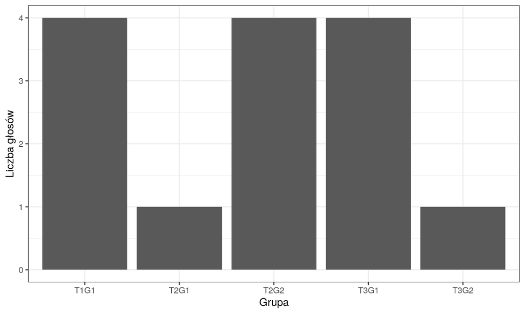

## Projekt 2

*Dzięki narzędziu chłopaków dowiedziałem się, że najprawdopodobniej moja firma przetrwa najbliższe dwa lata. Skoro przetrwa najbliższe dwa lata, a według wielu najbliższe dwa lata będą gospodarczo najtrudniejsze od lat 20. no to może uda się też przetrwać i dłużej, także dla mnie bardzo pozytywne przesłanie aplikacji i całej prezentacji.*

## Projekt 2

- Proszę dodać linki do aplikacji i repozytorium w repozytorium przedmiotu.
- Oceny są w USOS.

## Projekt 3

W ramach projektu 3 należy przygotować aplikację internetową, która pozwala testować wpływ rozmaitych błędów wizualizacyjnych na percepcję danych przedstawionych na wykresie. Aplikcja powinna zawierać przynajmniej **pięć** wykresów przedstawiających częste błędy wizualizacyjne (np. zbędny trzeci wymiar, wykresy kołowe) oraz pola w których użytkownik może wprowadzić informacje odczytane z wykresu, a także możliwość przejścia w tryb sprawdzania, gdzie:

- użytkownik porówna wprowadzone przez siebie wartości z rzeczywistymi,
- użytkownik zobaczy porównanie poprawnego wykresu z niepoprawnym.

## Projekt 3

Projekty można realizować z osobami z innej grupy ćwiczeniowej w grupie do 5 osób. Za projekt 3 można otrzymać do 100 punktów z czego:

- od 0 do 45 punktów za poprawność projektu (np. starannie wykonane wykresy).
- od 0 do 25 punktów za dodatkowy wysiłek włożony w projekt (np. wyszukanie błędów wizualizacyjnych, które nie były wprowadzone na wykładzie).
- od 0 do 30 punktów za ciekawą prezentację projektu w postaci filmiku.

## Projekt 3

Termin oddania projektu: 10-17.06.2020, 14:00.

Do 1.06. proszę zgłosić w repozytorium przedmiotu skład zespołu.

## Przykłady problemów wizualizacyjnych

Czytelność wykresu: poprawność odczytania danych przedstawionych na wykresie.

## Wykresy kołowe

[figure not shown]

Źródło: https://eagereyes.org/

## Wykresy kołowe

[Drew Skau, Robert Kosara, Arcs, Angles, or Areas: Individual Data Encodings in Pie and Donut Charts, EuroVis 2016](https://kosara.net/publications/Skau-EuroVis-2016.html)

## Porównywanie pól

[Robert Kosara, The Impact of Distribution and Chart Type on Part-to-Whole Comparisons. In Short Paper Proceedings of the Eurographics/IEEE VGTC Symposium on Visualization, 2019](https://kosara.net/papers/2019/Kosara-EuroVis-2019b.pdf)